# Additional_Project_NLP_Full_Code_Notebook_sbadwaik_Final_

## **Problem Statement**

### Business Context

The prices of the stocks of companies listed under a global exchange are influenced by a variety of factors, with the company's financial performance, innovations and collaborations, and market sentiment being factors that play a significant role. News and media reports can rapidly affect investor perceptions and, consequently, stock prices in the highly competitive financial industry. With the sheer volume of news and opinions from a wide variety of sources, investors and financial analysts often struggle to stay updated and accurately interpret its impact on the market. As a result, investment firms need sophisticated tools to analyze market sentiment and integrate this information into their investment strategies.

### Problem Definition

With an ever-rising number of news articles and opinions, an investment startup aims to leverage artificial intelligence to address the challenge of interpreting stock-related news and its impact on stock prices. They have collected historical daily news for a specific company listed under NASDAQ, along with data on its daily stock price and trade volumes.

As a member of the Data Science and AI team in the startup, you have been tasked with analyzing the data, developing an AI-driven sentiment analysis system that will automatically process and analyze news articles to gauge market sentiment, and summarizing the news at a weekly level to enhance the accuracy of their stock price predictions and optimize investment strategies. This will empower their financial analysts with actionable insights, leading to more informed investment decisions and improved client outcomes.

### Data Dictionary

- `Date` : The date the news was released
- `News` : The content of news articles that could potentially affect the company's stock price
- `Open` : The stock price (in \$) at the beginning of the day
- `High` : The highest stock price (in \$) reached during the day
- `Low` : The lowest stock price (in \$) reached during the day
- `Close` : The adjusted stock price (in \$) at the end of the day
- `Volume` : The number of shares traded during the day
- `Label` : The sentiment polarity of the news content
  - 1: positive
  - 0: neutral
  - -1: negative

## **Installing and Importing Necessary Libraries**

```python
# Installing the libraries with the specified version.

# Install the required libraries
%pip install -U sentence-transformers gensim transformers tqdm -q

# Upgrade the click package to resolve the dependency conflict
%pip install click --upgrade

# Check the version of scikit-learn
import sklearn
print(sklearn.__version__)

# Reinstall scikit-learn if necessary
%pip install --upgrade scikit-learn
```

**Note**:

- After running the above cell, kindly restart the runtime (for Google Colab) or notebook kernel (for Jupyter Notebook), and run all cells sequentially from the next cell.
- On executing the above line of code, you might see a warning regarding package dependencies. This error message can be ignored as the above code ensures that all necessary libraries and their dependencies are maintained to successfully execute the code in *this notebook*.

```python
# To manipulate and analyze data
import pandas as pd
import numpy as np

# To visualize data
import matplotlib.pyplot as plt
import seaborn as sns

# To used time-related functions
import time

# To parse JSON data
import json

# To build, tune, and evaluate ML models
from sklearn.tree import DecisionTreeClassifier
from sklearn.ensemble import (
    AdaBoostClassifier,
    GradientBoostingClassifier,
    RandomForestClassifier,
    BaggingClassifier,
)
from xgboost import XGBClassifier

from sklearn.model_selection import GridSearchCV
from sklearn.metrics import confusion_matrix, accuracy_score, f1_score, precision_score, recall_score

# To load/create word embeddings
from gensim.models import Word2Vec
from gensim.models import KeyedVectors
from gensim.scripts.glove2word2vec import glove2word2vec

# To work with transformer models
import torch
from sentence_transformers import SentenceTransformer

# To implement progress bar related functionalities
from tqdm import tqdm
tqdm.pandas()

# To suppress warnings.
import warnings
warnings.filterwarnings("ignore", category=FutureWarning)
warnings.filterwarnings("ignore", category=DeprecationWarning)
warnings.filterwarnings("ignore", category=UserWarning)
```

## **Loading the dataset**

```python
from google.colab import drive
drive.mount('/content/drive')
```

```python
# Load dataset
stocknews_df_org = pd.read_csv("/content/drive/MyDrive/Data_Science/PGP-AIML/Projects/Project5b-Stock Market News Sentiment Analysis and Summarization/stock_news.csv")
stocknews_df = stocknews_df_org.copy()
```

## **Data Overview**

```python
# Check dataset shape
stocknews_df.shape
```

```
(349, 8)
```

```python
# Print first five rows of the selected dataset
stocknews_df.head()
```

|  | Date | News | Open | High | Low | Close | Volume | Label |
| --- | --- | --- | --- | --- | --- | --- | --- | --- |
| 0 | 2019-01-02 | The tech sector experienced a significant dec... | 41.740002 | 42.244999 | 41.482498 | 40.246914 | 130672400 | -1 |
| 1 | 2019-01-02 | Apple lowered its fiscal Q1 revenue guidance ... | 41.740002 | 42.244999 | 41.482498 | 40.246914 | 130672400 | -1 |
| 2 | 2019-01-02 | Apple cut its fiscal first quarter revenue fo... | 41.740002 | 42.244999 | 41.482498 | 40.246914 | 130672400 | -1 |
| 3 | 2019-01-02 | This news article reports that yields on long... | 41.740002 | 42.244999 | 41.482498 | 40.246914 | 130672400 | -1 |
| 4 | 2019-01-02 | Apple's revenue warning led to a decline in U... | 41.740002 | 42.244999 | 41.482498 | 40.246914 | 130672400 | -1 |

```python
# Print last five rows of the selected dataset
stocknews_df.tail()
```

|  | Date | News | Open | High | Low | Close | Volume | Label |
| --- | --- | --- | --- | --- | --- | --- | --- | --- |
| 344 | 2019-04-30 | Media mogul Oprah Winfrey, known for influenc... | 50.764999 | 50.849998 | 49.7775 | 48.70879 | 186139600 | -1 |
| 345 | 2019-04-30 | European shares fell on Tuesday, with banks u... | 50.764999 | 50.849998 | 49.7775 | 48.70879 | 186139600 | -1 |
| 346 | 2019-04-30 | This article reports that the S&P 500 reached... | 50.764999 | 50.849998 | 49.7775 | 48.70879 | 186139600 | -1 |
| 347 | 2019-04-30 | The Federal Reserve is anticipated to keep in... | 50.764999 | 50.849998 | 49.7775 | 48.70879 | 186139600 | -1 |
| 348 | 2019-04-30 | In the first quarter, South Korea's Samsung E... | 50.764999 | 50.849998 | 49.7775 | 48.70879 | 186139600 | 0 |

```python
# Print data info including columns and ddataype details
stocknews_df.info()
```

```
<class 'pandas.core.frame.DataFrame'>
RangeIndex: 349 entries, 0 to 348
Data columns (total 8 columns):
 #   Column  Non-Null Count  Dtype
---  ------  --------------  -----
 0   Date    349 non-null    object
 1   News    349 non-null    object
 2   Open    349 non-null    float64
 3   High    349 non-null    float64
 4   Low     349 non-null    float64
 5   Close   349 non-null    float64
 6   Volume  349 non-null    int64
 7   Label   349 non-null    int64
dtypes: float64(4), int64(2), object(2)
memory usage: 21.9+ KB
```

Obervations: There are 349 rows and 8 columns. No Null data. 4 coulmns are float, 2 are integer and 2 are object.

```python
stocknews_df.isnull().sum()
```

|  | 0 |
| --- | --- |
| Date | 0 |
| News | 0 |
| Open | 0 |
| High | 0 |
| Low | 0 |
| Close | 0 |
| Volume | 0 |
| Label | 0 |

**dtype:** int64

Obervations: No missing values → no imputation needed. Downstream models/plots won’t choke on NaNs.

```python
stocknews_df.describe().T
```

|  | count | mean | std | min | 25% | 50% | 75% | max |
| --- | --- | --- | --- | --- | --- | --- | --- | --- |
| Open | 349.0 | 4.622923e+01 | 6.442817e+00 | 3.756750e+01 | 4.174000e+01 | 4.597500e+01 | 5.070750e+01 | 6.681750e+01 |
| High | 349.0 | 4.670046e+01 | 6.507321e+00 | 3.781750e+01 | 4.224500e+01 | 4.602500e+01 | 5.085000e+01 | 6.706250e+01 |
| Low | 349.0 | 4.574539e+01 | 6.391976e+00 | 3.730500e+01 | 4.148250e+01 | 4.564000e+01 | 4.977750e+01 | 6.586250e+01 |
| Close | 349.0 | 4.492632e+01 | 6.398338e+00 | 3.625413e+01 | 4.024691e+01 | 4.459692e+01 | 4.911079e+01 | 6.480523e+01 |
| Volume | 349.0 | 1.289482e+08 | 4.317031e+07 | 4.544800e+07 | 1.032720e+08 | 1.156272e+08 | 1.511252e+08 | 2.444392e+08 |
| Label | 349.0 | -5.444126e-02 | 7.151192e-01 | -1.000000e+00 | -1.000000e+00 | 0.000000e+00 | 0.000000e+00 | 1.000000e+00 |

Observations:

Prices (Open/High/Low/Close)

- Means: mid-$40s; std ≈ 6.4–6.5.
- Range: mins ~$36–38; maxs ~$65–67 → ~30 USD spread across the period.
- Median < Mean on most prices → slight right-skew (occasional higher values).

Close vs Open

- Mean Close (44.93) < Mean Open (46.23) by ~1.30 → mild downward drift on average across sampled days.

Volume

- Mean: ~128.9M; std: ~43.2M; min: 45.4M; max: 244.4M.
- Observation: High variability (CV ≈ 0.33). Expect spikes on big-news days.

Label

- Values in {-1, 0, 1}; mean ≈ −0.054; 25% = −1, 50% = 0, 75% = 0.
- Observations:
  - 0 is the median/mode, so many neutrals.
  - At least 25% negatives (−1), and ≤25% positives (since 75th percentile is 0).
  - Overall slightly tilted negative (mean < 0). Plan for class imbalance checks.

```python
stocknews_df.nunique()
```

|  | 0 |
| --- | --- |
| Date | 71 |
| News | 349 |
| Open | 70 |
| High | 70 |
| Low | 71 |
| Close | 71 |
| Volume | 71 |
| Label | 3 |

**dtype:** int64

Observations: Unique dates: 71.

- Unique news items: 349 (every row’s News is unique).
- Unique OHLC/Volume: ~70–71 each (matches daily granularity).
- Observation: About 349 / 71 ≈ 4.9 headlines per trading day on average. This means multiple rows share the same day’s OHLC/Label—possible overweighting days with many headlines; may have to consider aggregating by day/week for training/eval.

```python
stocknews_df.duplicated().sum()
```

```
0
```

Observations:

- 0 duplicates; no exact row duplicates.

```python
stocknews_df.columns.tolist()
```

```
['Date', 'News', 'Open', 'High', 'Low', 'Close', 'Volume', 'Label']
```

Observation: Confirms expected 8 columns; nothing extra/hidden.

```python
stocknews_df.Date.info()
```

```
<class 'pandas.core.series.Series'>
RangeIndex: 349 entries, 0 to 348
Series name: Date
Non-Null Count  Dtype
--------------  -----
349 non-null    object
dtypes: object(1)
memory usage: 2.9+ KB
```

Observations:

- Date is still object before conversion.
- Time ops (groupby week, sorting) require conversion to datetime

```python
stocknews_df["Date"] = pd.to_datetime(stocknews_df["Date"])
stocknews_df["Date"].dt.year.value_counts()
```

| Date | count |
| --- | --- |
| 2019 | 349 |

**dtype:** int64

Observations:

- All rows are 2019 (349 entries).
- Time window is limited (~71 trading days ≈ 3–4 months).

## **Exploratory Data Analysis**

### Univariate Analysis

- Distribution of individual variables
- Compute and check the distribution of the length of news content

#### Observations on Label

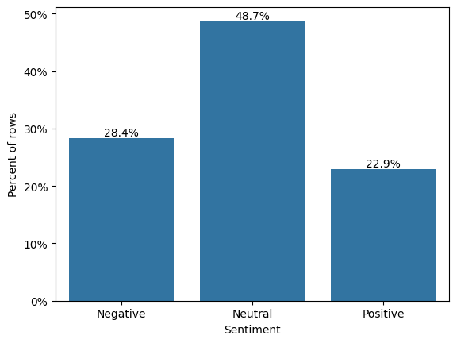

```python
# sns.countplot(data=stocknews_df, x="Label", stat="percent");


from matplotlib.ticker import PercentFormatter

label_map = {-1: "Negative", 0: "Neutral", 1: "Positive"}
order = [-1, 0, 1]

ax = sns.countplot(data=stocknews_df, x="Label", order=order, stat="percent")
ax.set_xlabel("Sentiment")
ax.set_ylabel("Percent of rows")
ax.yaxis.set_major_formatter(PercentFormatter(xmax=100))
ax.set_xticklabels([label_map[i] for i in order])

for container in ax.containers:
    ax.bar_label(container, fmt="%.1f%%")

plt.show()
```

Obsevation:

- 28.4% are Negative (-1)
- 48.7% are Neutral (0)
- 22.9% are Positive (1)

#### Density Plot of Price (Open,High,Low,Close)

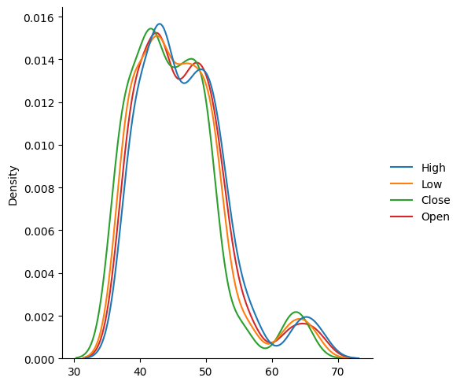

```python
sns.displot(data=stocknews_df[['High','Low','Close','Open']], kind="kde", palette="tab10"); # To plot a density plot of ["Open","High","Low","Close"] all in a single plot
```

Observations:

#### Observations on Volume

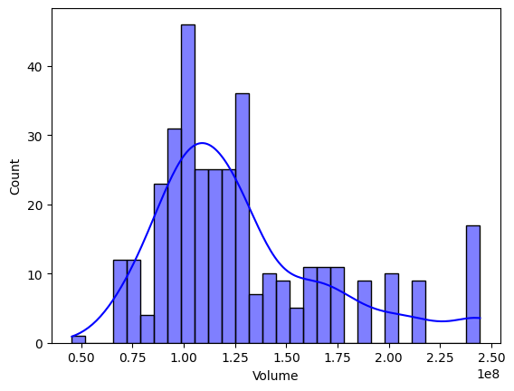

```python
sns.histplot(stocknews_df, x='Volume', bins=30, kde=True, color='blue'); # Code to plot a histogram of Volume
```

- Right-skewed distribution. Most trading days cluster around ~0.9–1.3×10⁸ shares, with a long right tail out to ~2.4×10⁸.
- High variability, so volume swings a lot from day to day.
- Shape ~ unimodal with fat right tail. No strong left tail; lower volumes stay well above the lower fence.

#### Observations on News length

```python
#Calculating the total number of words present in the news content.
stocknews_df['news_len'] = stocknews_df['News'].apply(lambda x: len(x.split(' ')))


stocknews_df['news_len'].describe().T   # The code to print the statistical summary for the news content length
```

|  | news_len |
| --- | --- |
| count | 349.000000 |
| mean | 49.312321 |
| std | 5.727770 |
| min | 19.000000 |
| 25% | 46.000000 |
| 50% | 50.000000 |
| 75% | 53.000000 |
| max | 61.000000 |

**dtype:** float64

Observation:

- Mean = 49.31, Median = 50 → lengths are very consistent and centered ~50 words.
- Std = 5.73; IQR = 53–46 = 7 → tight spread (CV ≈ 11.6%). Most items are within a narrow band.
- Range = 19 to 61 words → a few short items; upper lengths stay moderate.
- Median > Mean (50 > 49.31) → slight left-skew caused by some shorter texts.
- Outliers:
  - Lower fence = 46 − 1.5×7 = 35.5; anything <35–36 words is a short outlier.
  - Upper fence = 53 + 1.5×7 = 63.5; max 61 is not an upper outlier.
  - Only short outliers are present.

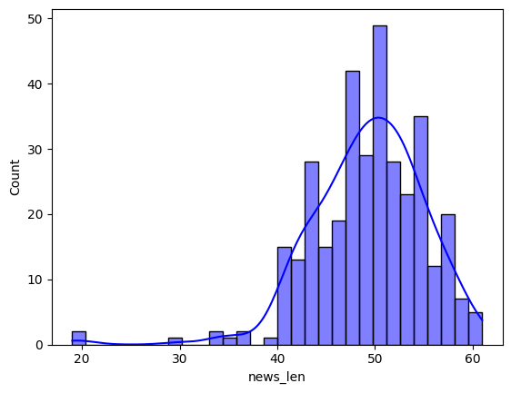

```python
sns.histplot(data=stocknews_df,x="news_len",kde=True,bins=30,color='blue',);  # The code to plot a histogram of news_len column
```

Observations:

- Tight center around ~50 words. The peak is near 49–51, matching your mean≈49.3 and median=50.
- Small spread. Most headlines are in 45–55 words; std≈5.7 and IQR=46–53 → very consistent lengths.
- Mild left-skew from short items. A few bars between ~20–35 words create a thin left tail; these are short outliers.
- Right tail is light. A handful approach 60–61 words, but nothing extreme.
- Unimodal & well-behaved. Shape is roughly normal with slight left skew; no evidence of multi-regime lengths.

### Bivariate Analysis

- Correlation
- Sentiment Polarity vs Price
- Date vs Price

**Note**: The above points are listed to provide guidance on how to approach bivariate analysis. Analysis has to be done beyond the above listed points to get maximum scores.

##### Correlation

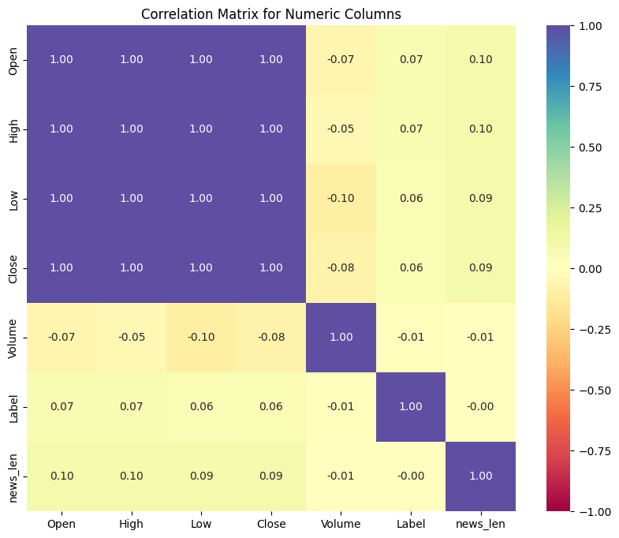

```python
# Select only the numeric columns from the stocknews_df DataFrame
numeric_columns = stocknews_df.select_dtypes(include='number')

# Plot the correlation matrix fir the numeric columns
plt.figure(figsize=(10, 8))
sns.heatmap(
    numeric_columns.corr(), annot=True, vmin=-1, vmax=1, fmt=".2f", cmap="Spectral"
)

# Set plot labels and title
plt.title('Correlation Matrix for Numeric Columns')
plt.show()
```

Observations:

- OHLC are ~perfectly correlated (≈1.00) with each other. That’s expected because each day’s Open/High/Low/Close repeat across multiple rows (one row per headline). This duplicates the same OHLC values many times and makes them appear identical across rows. It’s multicollinearity, not a meaningful relationship.
- Volume vs prices: small negative correlations (about −0.05 to −0.10). Weak inverse association; could change after proper daily aggregation or when using returns instead of levels.
- Label vs numeric levels: essentially near zero with OHLC (~+0.06–0.07) and ~0 with Volume.
- news_len vs everything: tiny positive with prices (~+0.09–0.10), ~0 with Label. Length adds little predictive value; at best keep as a minor auxiliary feature or drop.

##### Sentiment Polarity vs Price

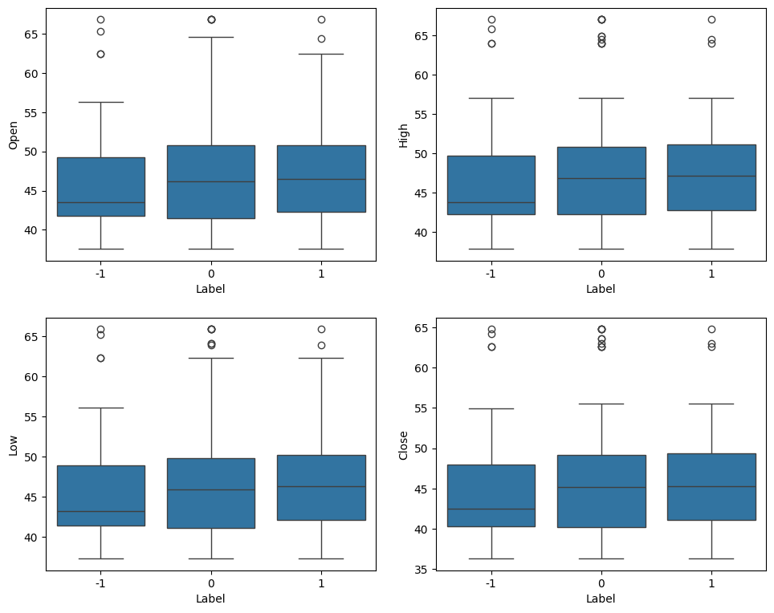

```python
plt.figure(figsize=(10, 8))

for i, variable in enumerate(['Open', 'High', 'Low', 'Close']):
    plt.subplot(2, 2, i + 1)
    sns.boxplot(data=stocknews_df, x="Label", y=variable)
    plt.tight_layout(pad=2)

plt.show()
```

Observations:

- Medians are very close across labels. For all four prices, the median for +1 looks only slightly above 0, which is only slightly above −1. The shifts are small.
- IQRs heavily overlap for all labels → distributions are very similar. Any difference in central tendency is weak.
- Spread/outliers are comparable across labels. And I see high-value outliers in every class; nothing unique to a specific sentiment.
- The small “increase” in medians from −1 → 0 → +1 could just reflect the price regime (days when the stock level was higher happened to have more neutral/positive headlines), not a true effect of sentiment.

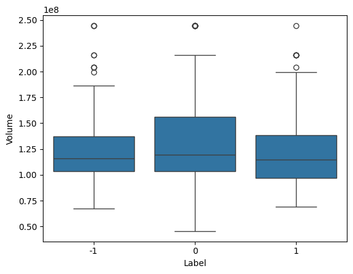

```python
# Label Vs Volume boxplot
sns.boxplot(
    data=stocknews_df, x="Label", y="Volume"
)
```

##### Date vs Price

```python
stock_daily = stocknews_df.groupby('Date').agg(
    {
        'Open': 'mean',
        'High': 'mean',
        'Low': 'mean',
        'Close': 'mean',
        'Volume': 'mean',
    }
).reset_index()  # Group the 'stocks' DataFrame by the 'Date' column

stock_daily.set_index('Date', inplace=True)
stock_daily.head()
```

| Date | Open | High | Low | Close | Volume |
| --- | --- | --- | --- | --- | --- |
| 2019-01-02 | 41.740002 | 42.244999 | 41.482498 | 40.246914 | 130672400.0 |
| 2019-01-03 | 43.570000 | 43.787498 | 43.222500 | 42.470604 | 103544800.0 |
| 2019-01-04 | 47.910000 | 47.919998 | 47.095001 | 46.419842 | 111448000.0 |
| 2019-01-07 | 50.792500 | 51.122501 | 50.162498 | 49.110790 | 109012000.0 |
| 2019-01-08 | 53.474998 | 54.507500 | 51.685001 | 50.787209 | 216071600.0 |

Observations:

- Now, we have one row per trading day (should be ~71 rows given your earlier nunique).
- The OHLC/Volume values look like standard daily figures (e.g., 2019-01-08 volume ~2.16e8, which is one of the spike days you saw).
- Using mean is harmless here because, in your dataset, each day already has a single OHLCV that’s repeated across headlines; the mean equals that value.

```python
# to confirm that Using mean is harmless here because, in your dataset, each day already has a single OHLCV that’s repeated across headlines; the mean equals that value.
stocknews_df.groupby('Date')[['Open','High','Low','Close','Volume']].nunique().max()
# Expect all 1s
```

|  | 0 |
| --- | --- |
| Open | 1 |
| High | 1 |
| Low | 1 |
| Close | 1 |
| Volume | 1 |

**dtype:** int64

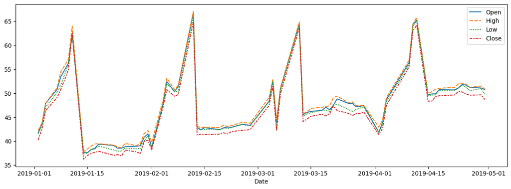

```python
# Lineplot of all the variables except Volume
plt.figure(figsize=(15,5))
sns.lineplot(stock_daily.drop("Volume", axis=1))
```

Observations:

- Lockstep movement: The four series move together (as they should). High is consistently above Open/Close, Low below—intraday structure looks sane.
- Regime-like “sawtooth” pattern: I see repeated ramps up to a local peak (≈63–68) followed by an abrupt drop to the low-40s, then another ramp. This repeats several times (≈mid-Jan, mid-Feb, mid-Mar, mid-Apr).
- Large overnight gaps: Those vertical drops are too large to be normal day-to-day noise. They’re either (a) genuine gap moves on specific days or (b) a data/aggregation artifact.
- Consistency across O/H/L/C: The same jumps appear in all four lines, which means it’s not a plotting glitch specific to one column.

##### Volume vs Close Price

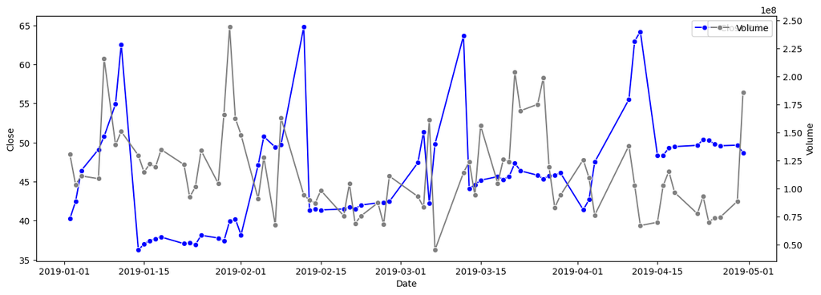

```python
# Create a figure and axis
fig, ax1 = plt.subplots(figsize=(15,5))

# Lineplot on primary y-axis
sns.lineplot(data=stock_daily.reset_index(), x='Date', y='Close', ax=ax1, color='blue', marker='o', label='Close Price')

# Create a secondary y-axis
ax2 = ax1.twinx()

# Lineplot on secondary y-axis
sns.lineplot(data=stock_daily.reset_index(), x='Date', y='Volume', ax=ax2, color='gray', marker='o', label='Volume')

ax1.legend(bbox_to_anchor=(1,1))
```

Observations:

## **Data Preprocessing**

```python
# Statistical summary of the 'Date' column
# stocknews_df["Date"].describe()
stocknews_df['Date'].dt.strftime('%Y-%m-%d').describe()
```

|  | Date |
| --- | --- |
| count | 349 |
| unique | 71 |
| top | 2019-01-03 |
| freq | 28 |

**dtype:** object

```python
# Check that the 'Date' column is in datetime format
stocknews_df['Date'] = pd.to_datetime(stocknews_df['Date'])

# Check the relevant date components for summarization
stocknews_df['Year'] = stocknews_df['Date'].dt.year
stocknews_df['Month'] = stocknews_df['Date'].dt.month
stocknews_df['Day'] = stocknews_df['Date'].dt.day

# Print the statistical summary of the 'Date' column components
print("Year Summary:")
print(stocknews_df['Year'].describe())
print("\nMonth Summary:")
print(stocknews_df['Month'].describe())
print("\nDay Summary:")
print(stocknews_df['Day'].describe())
```

```
Year Summary:
count     349.0
mean     2019.0
std         0.0
min      2019.0
25%      2019.0
50%      2019.0
75%      2019.0
max      2019.0
Name: Year, dtype: float64

Month Summary:
count    349.000000
mean       2.077364
std        1.177997
min        1.000000
25%        1.000000
50%        2.000000
75%        3.000000
max        4.000000
Name: Month, dtype: float64

Day Summary:
count    349.000000
mean      15.389685
std        9.351840
min        1.000000
25%        6.000000
50%       15.000000
75%       24.000000
max       31.000000
Name: Day, dtype: float64
```

Observations:

- Year
  - All rows are 2019 (std = 0).
  - Implication: your analysis covers a single year slice only → limited temporal generalization.
- Month
  - min=1, max=4, median=2 → data spans Jan → Apr 2019 (mostly Jan–Mar, some Apr).
  - Matches earlier: ~71 unique trading days with 349 headlines → ~5 headlines/day on average.
  - Implication: good for weekly summaries, but not a full-year/seasonality study.
- Day (day-of-month)
  - Values run 1–31, median ≈ 15, fairly broad spread (std ≈ 9.35).
  - This isn’t very informative for markets because weekends/holidays distort day-of-month counts. Day-of-week is more useful.

##### Train-test-validation Split

```python
# Select all rows where the 'Date' is before '2019-04-01'
X_train = stocknews_df[(stocknews_df['Date'] < '2019-04-01')].reset_index()

# Select all rows where the 'Date' is from '2019-04-01 to '2019-04-16' (excluded)
X_val = stocknews_df[(stocknews_df['Date'] >= '2019-04-01') & (stocknews_df['Date'] < '2019-04-16')].reset_index()

# Select all rows where the 'Date' is from '2019-04-16' till the end.
X_test = stocknews_df[stocknews_df['Date'] >= '2019-04-16'].reset_index()
```

```python
# Set 'Label' column as the target variable
y_train = X_train["Label"].copy()
y_val = X_val["Label"].copy()
y_test = X_test["Label"].copy()
```

```python
# Print the shape of X_train,X_val,X_test,y_train,y_val and y_test
print("Train data shape: ",X_train.shape)
print("Validation data shape: ",X_val.shape)
print("Test data shape ",X_test.shape)

print("Train label shape: ",y_train.shape)
print("Validation label shape: ",y_val.shape)
print("Test label shape: ",y_test.shape)
```

```
Train data shape:  (286, 13)
Validation data shape:  (21, 13)
Test data shape  (42, 13)
Train label shape:  (286,)
Validation label shape:  (21,)
Test label shape:  (42,)
```

```python
X_train.head()
```

|  | index | Date | News | Open | High | Low | Close | Volume | Label | news_len | Year | Month | Day |
| --- | --- | --- | --- | --- | --- | --- | --- | --- | --- | --- | --- | --- | --- |
| 0 | 0 | 2019-01-02 | The tech sector experienced a significant dec... | 41.740002 | 42.244999 | 41.482498 | 40.246914 | 130672400 | -1 | 46 | 2019 | 1 | 2 |
| 1 | 1 | 2019-01-02 | Apple lowered its fiscal Q1 revenue guidance ... | 41.740002 | 42.244999 | 41.482498 | 40.246914 | 130672400 | -1 | 51 | 2019 | 1 | 2 |
| 2 | 2 | 2019-01-02 | Apple cut its fiscal first quarter revenue fo... | 41.740002 | 42.244999 | 41.482498 | 40.246914 | 130672400 | -1 | 49 | 2019 | 1 | 2 |
| 3 | 3 | 2019-01-02 | This news article reports that yields on long... | 41.740002 | 42.244999 | 41.482498 | 40.246914 | 130672400 | -1 | 51 | 2019 | 1 | 2 |
| 4 | 4 | 2019-01-02 | Apple's revenue warning led to a decline in U... | 41.740002 | 42.244999 | 41.482498 | 40.246914 | 130672400 | -1 | 50 | 2019 | 1 | 2 |

```python
X_val.head()
```

|  | index | Date | News | Open | High | Low | Close | Volume | Label | news_len | Year | Month | Day |
| --- | --- | --- | --- | --- | --- | --- | --- | --- | --- | --- | --- | --- | --- |
| 0 | 286 | 2019-04-02 | Apple and other consumer brands, including LV... | 41.852501 | 42.915001 | 41.8200 | 41.390125 | 125982000 | 0 | 45 | 2019 | 4 | 2 |
| 1 | 287 | 2019-04-02 | Swatch Group successfully defended its use of... | 41.852501 | 42.915001 | 41.8200 | 41.390125 | 125982000 | 0 | 47 | 2019 | 4 | 2 |
| 2 | 288 | 2019-04-02 | In premarket trade Tuesday, Apple's NASDAQ AA... | 41.852501 | 42.915001 | 41.8200 | 41.390125 | 125982000 | 0 | 35 | 2019 | 4 | 2 |
| 3 | 289 | 2019-04-02 | In US markets, futures for the Dow, S&P 500, ... | 41.852501 | 42.915001 | 41.8200 | 41.390125 | 125982000 | -1 | 47 | 2019 | 4 | 2 |
| 4 | 290 | 2019-04-03 | Japan Display, a key Apple supplier, is set t... | 43.922501 | 44.437500 | 43.4925 | 42.684212 | 109744800 | 1 | 56 | 2019 | 4 | 3 |

```python
X_test.head()
```

|  | index | Date | News | Open | High | Low | Close | Volume | Label | news_len | Year | Month | Day |
| --- | --- | --- | --- | --- | --- | --- | --- | --- | --- | --- | --- | --- | --- |
| 0 | 307 | 2019-04-16 | In a complex trial in San Diego, Apple accuse... | 49.865002 | 50.342499 | 49.639999 | 48.364113 | 102785600 | 0 | 54 | 2019 | 4 | 16 |
| 1 | 308 | 2019-04-17 | Taiwan business tycoon Terry Gou, chairman of... | 49.884998 | 50.845001 | 49.652500 | 49.305897 | 115627200 | 0 | 44 | 2019 | 4 | 17 |
| 2 | 309 | 2019-04-17 | Chinese video-sharing app TikTok, owned by By... | 49.884998 | 50.845001 | 49.652500 | 49.305897 | 115627200 | 0 | 52 | 2019 | 4 | 17 |
| 3 | 310 | 2019-04-17 | TomTom, a Dutch navigation and digital maps f... | 49.884998 | 50.845001 | 49.652500 | 49.305897 | 115627200 | 1 | 48 | 2019 | 4 | 17 |
| 4 | 311 | 2019-04-17 | In a volatile trading session, the S&P 500 wa... | 49.884998 | 50.845001 | 49.652500 | 49.305897 | 115627200 | 1 | 49 | 2019 | 4 | 17 |

```python
# label_map = {-1: "Negative", 0: "Neutral", 1: "Positive"}
# y_train_named = y_train.rename("Label").map(label_map)
# y_train_named.head()

y_train.head()
```

|  | Label |
| --- | --- |
| 0 | -1 |
| 1 | -1 |
| 2 | -1 |
| 3 | -1 |
| 4 | -1 |

**dtype:** int64

```python
y_val.head()
```

|  | Label |
| --- | --- |
| 0 | 0 |
| 1 | 0 |
| 2 | 0 |
| 3 | -1 |
| 4 | 1 |

**dtype:** int64

```python
y_test.head()
```

|  | Label |
| --- | --- |
| 0 | 0 |
| 1 | 0 |
| 2 | 0 |
| 3 | 1 |
| 4 | 1 |

**dtype:** int64

## **Word Embeddings**

### Word2Vec

```python
# Creating a list of all words in our data
words_list = [item.split(" ") for item in stocknews_df['News'].values]
```

```python
# Creating an instance of Word2Vec
vec_size = 300
model_W2V = Word2Vec(words_list, vector_size = vec_size, min_count = 1, window=5, workers = 6)
```

```python
# Checking the size of the vocabulary
print("Length of the vocabulary is", len(list(model_W2V.wv.key_to_index)))
```

```
Length of the vocabulary is 4682
```

Review the results of embeddings obtained using the model.

```python
# Checking the word embedding of a random word
word = "stock"
model_W2V.wv[word]
```

[output not shown]

[output cut: 21 more lines]

[output not shown]

```python
# Checking the word embedding of a random word
word = "economy"
model_W2V.wv[word]
```

[output not shown]

[output cut: 21 more lines]

[output not shown]

```python
# Retrieving the words present in the Word2Vec model's vocabulary
words = list(model_W2V.wv.key_to_index.keys())

# Retrieving word vectors for all the words present in the model's vocabulary
wvs = model_W2V.wv[words].tolist()

# Creating a dictionary of words and their corresponding vectors
word_vector_dict = dict(zip(words, wvs))

print("Length of the dictionary is ", len(word_vector_dict))
```

```
Length of the dictionary is  4682
```

```python
def average_vectorizer_Word2Vec(doc):
    # Initializing a feature vector for the sentence
    feature_vector = np.zeros((vec_size,), dtype="float64")

    # Creating a list of words in the sentence that are present in the model vocabulary
    words_in_vocab = [word for word in doc.split() if word in words]

    # adding the vector representations of the words
    for word in words_in_vocab:
        feature_vector += np.array(word_vector_dict[word])

    # Dividing by the number of words to get the average vector
    if len(words_in_vocab) != 0:
        feature_vector /= len(words_in_vocab)

    return feature_vector
```

```python
# creating a dataframe of the vectorized documents
# Each news item -> fixed-length vector (len = vec_size); we also time the whole step.

start = time.time()  # start timing

# TRAIN: apply the average_vectorizer_Word2Vec function to each headline in X_train["News"].
# .apply(...) returns a Series of vectors; .tolist() makes it a list of lists suitable for DataFrame construction.
# We then name columns Feature 0 ... Feature (vec_size-1).
X_train_wv = pd.DataFrame(
    X_train["News"].apply(average_vectorizer_Word2Vec).tolist(),
    columns=['Feature '+str(i) for i in range(vec_size)]
    )

# VALIDATION: same transformation for the validation split
X_val_wv = pd.DataFrame(
    X_val["News"].apply(average_vectorizer_Word2Vec).tolist(),
    columns=['Feature '+str(i) for i in range(vec_size)]
    )

# TEST: same transformation for the test split
X_test_wv = pd.DataFrame(
    X_test["News"].apply(average_vectorizer_Word2Vec).tolist(),
    columns=['Feature '+str(i) for i in range(vec_size)]
    )

end = time.time()
print('Time taken ', (end-start)) # total wall-clock time for all three transforms
```

```
Time taken  0.5308098793029785
```

```python
print(X_train_wv.shape, X_val_wv.shape, X_test_wv.shape)
```

```
(286, 300) (21, 300) (42, 300)
```

### GloVe

```python
# load the Stanford GloVe model
filename = '/content/drive/MyDrive/Data_Science/PGP-AIML/Projects/Project5b-Stock Market News Sentiment Analysis and Summarization/glove.6B.100d.txt.word2vec'
glove_model = KeyedVectors.load_word2vec_format(filename, binary=False)
```

```python
# Checking the size of the vocabulary
print("Length of the vocabulary is", len(glove_model.index_to_key))
```

```
Length of the vocabulary is 400000
```

Review the results of embeddings obtained using the model.

```python
# Checking the word embedding of a random word
word = "stock"
glove_model[word]
```

```
array([ 8.6341e-01,  6.9648e-01,  4.5794e-02, -9.5708e-03, -2.5498e-01,
       -7.4666e-01, -2.2086e-01, -4.4615e-01, -1.0423e-01, -9.9931e-01,
        7.2550e-02,  4.5049e-01, -5.9912e-02, -5.7837e-01, -4.6540e-01,
        4.3429e-02, -5.0570e-01, -1.5442e-01,  9.8250e-01, -8.1571e-02,
        2.6523e-01, -2.3734e-01,  9.7675e-02,  5.8588e-01, -1.2948e-01,
       -6.8956e-01, -1.2811e-01, -5.2265e-02, -6.7719e-01,  3.0190e-02,
        1.8058e-01,  8.6121e-01, -8.3206e-01, -5.6887e-02, -2.9578e-01,
        4.7180e-01,  1.2811e+00, -2.5228e-01,  4.9557e-02, -7.2455e-01,
        6.6758e-01, -1.1091e+00, -2.0493e-01, -5.8669e-01, -2.5375e-03,
        8.2777e-01, -4.9102e-01, -2.6475e-01,  4.3015e-01, -2.0516e+00,
       -3.3208e-01,  5.1845e-02,  5.2646e-01,  8.7452e-01, -9.0237e-01,
       -1.7366e+00, -3.4727e-01,  1.6590e-01,  2.7727e+00,  6.5756e-02,
       -4.0363e-01,  3.8252e-01, -3.0787e-01,  5.9202e-01,  1.3468e-01,
       -3.3851e-01,  3.3646e-01,  2.0950e-01,  8.5905e-01,  5.1865e-01,
       -1.0657e+00, -2.6371e-02, -3.1349e-01,  2.3231e-01, -7.0192e-01,
       -5.5737e-01, -2.3418e-01,  1.3563e-01, -1.0016e+00, -1.4221e-01,
        1.0372e+00,  3.5880e-01, -4.2608e-01, -1.9386e-01, -3.7867e-01,
       -6.9646e-01, -3.9989e-01, -5.7782e-01,  1.0132e-01,  2.0123e-01,
       -3.7153e-01,  5.0837e-01, -3.7758e-01, -2.6205e-01, -9.3676e-01,
        1.0053e+00,  8.4393e-01, -2.4698e-01,  1.7339e-01,  9.4473e-01],
      dtype=float32)
```

```python
# Checking the word embedding of a random word
word = "economy"
glove_model[word]
```

```
array([-0.19382  ,  1.017    ,  1.076    ,  0.02954  , -0.39192  ,
       -1.3891   , -0.87873  , -0.63162  ,  0.9643   , -0.43035  ,
       -0.34868  ,  0.22736  , -0.40296  ,  0.15641  , -0.16813  ,
       -0.15343  , -0.15799  , -0.27612  ,  0.18088  , -0.28386  ,
        0.49847  ,  0.29864  ,  0.32353  ,  0.18108  , -0.59623  ,
       -0.54165  , -0.70019  , -0.64956  , -0.69063  ,  0.18084  ,
       -0.38581  ,  0.56086  , -0.40313  , -0.38777  , -0.70615  ,
        0.20657  ,  0.34171  , -0.23393  , -0.35882  , -0.2201   ,
       -0.76182  , -1.2047   ,  0.4339   ,  1.1656   ,  0.1836   ,
       -0.21601  ,  0.93198  , -0.059616 , -0.11624  , -1.3259   ,
       -0.79772  , -0.0074957, -0.0889   ,  1.4749   ,  0.31157  ,
       -2.2952   , -0.058351 ,  0.39353  ,  1.4983   ,  0.74023  ,
       -0.20109  ,  0.098124 , -0.73081  , -0.32294  ,  0.16703  ,
        0.87431  , -0.041624 , -0.51022  ,  1.0737   , -0.4257   ,
        1.0581   ,  0.19859  , -0.60087  , -0.33906  ,  0.60243  ,
       -0.091581 , -0.47201  ,  0.74933  , -0.60168  , -0.44178  ,
        0.77391  ,  0.81114  , -1.2889   ,  0.32055  , -0.36117  ,
       -0.88078  ,  0.055524 , -0.26837  , -0.33688  , -1.4359   ,
        0.85666  ,  0.32025  , -0.15361  , -0.30208  , -0.38208  ,
        0.30508  ,  0.75374  , -0.68041  ,  0.98619  , -0.19628  ],
      dtype=float32)
```

```python
# Retrieving the words present in the GloVe model's vocabulary
glove_words = glove_model.index_to_key

# Creating a dictionary of words and their corresponding vectors
glove_word_vector_dict = dict(zip(glove_model.index_to_key,list(glove_model.vectors)))
```

```python
vec_size=100
```

```python
def average_vectorizer_GloVe(doc):
    # Initializing a feature vector for the sentence
    feature_vector = np.zeros((vec_size,), dtype="float64")

    # Creating a list of words in the sentence that are present in the model vocabulary
    words_in_vocab = [word for word in doc.split() if word in glove_words]

    # adding the vector representations of the words
    for word in words_in_vocab:
        feature_vector += np.array(glove_word_vector_dict[word])

    # Dividing by the number of words to get the average vector
    if len(words_in_vocab) != 0:
        feature_vector /= len(words_in_vocab)

    return feature_vector
```

```python
# Creating a dataframe of the vectorized documents
# This section converts text news articles into numerical feature vectors using the GloVe-based average vectorizer.
# It also measures the time taken for this transformation.
start = time.time()  # Record the start time to calculate processing duration later.

# Apply the GloVe average vectorizer to each news article in the training set,
# convert the list of resulting vectors into a DataFrame,
# and assign column names as 'Feature 0', 'Feature 1', ..., up to vec_size-1.
X_train_gl = pd.DataFrame(
    X_train["News"].apply(average_vectorizer_GloVe).tolist(),
    columns=['Feature '+str(i) for i in range(vec_size)]
    )

# Repeat the same transformation for the validation dataset.
X_val_gl = pd.DataFrame(
    X_val["News"].apply(average_vectorizer_GloVe).tolist(),
    columns=['Feature '+str(i) for i in range(vec_size)]
    )

# Repeat the same transformation for the test dataset.
X_test_gl = pd.DataFrame(
    X_test["News"].apply(average_vectorizer_GloVe).tolist(),
    columns=['Feature '+str(i) for i in range(vec_size)]
    )

# Repeat the same transformation for the test dataset.
end = time.time()
print('Time taken ', (end-start)) # total wall-clock time for all three transforms
```

```
Time taken  23.621132612228394
```

```python
# Print the shapes of the final dataframes
print(X_train_gl.shape, X_val_gl.shape, X_test_gl.shape)
```

```
(286, 100) (21, 100) (42, 100)
```

### Sentence Transformer

#### Defining the model

```python
#Defining the model
model = SentenceTransformer('sentence-transformers/all-MiniLM-L6-v2')
```

#### Encoding the dataset

```python
# setting the device to GPU if available, else CPU
device = torch.device("cuda" if torch.cuda.is_available() else "cpu")

print(f"Here Using device: {device}")
```

```
Here Using device: cuda
```

```python
# Encoding the dataset
start = time.time()

# Apply Sentence Transformer on 'News' column
X_train_st = model.encode(X_train["News"].values, show_progress_bar=True, device=device)

# Apply Sentence Transformer on 'News' column
X_val_st = model.encode(X_val["News"].values, show_progress_bar=True, device=device)

# Apply Sentence Transformer on 'News' column
X_test_st = model.encode(X_test["News"].values, show_progress_bar=True, device=device)

end = time.time()
print("Time taken ",(end-start))
```

```
Time taken  0.9801714420318604
```

```python
# Print the shapes of the final dataframes
print(X_train_st.shape, X_val_st.shape, X_test_st.shape)
```

```
(286, 384) (21, 384) (42, 384)
```

- Each news content has been converted to a 384-dimensional vector.

## **Sentiment Analysis**

### Model Evaluation Criterion

For financial sentiment with 3 classes (−1, 0, +1) and embeddings (Word2Vec, GloVe, Sentence-Transformer), pick your primary metric based on the business goal, then support it with a small, consistent set of secondary metrics.

### Utility Functions

```python
def plot_confusion_matrix(model, predictors, target):
    """
    Plot a confusion matrix to visualize the performance of a classification model.

    Parameters:
    actual (array-like): The true labels.
    predicted (array-like): The predicted labels from the model.

    Returns:
    None: Displays the confusion matrix plot.
    """
    pred = model.predict(predictors)  # Make predictions using the classifier.

    cm = confusion_matrix(target, pred)  # Compute the confusion matrix.

    plt.figure(figsize=(5, 4))  # Create a new figure with a specified size.
    label_list = [0, 1,-1]  # Define the labels for the confusion matrix.
    sns.heatmap(cm, annot=True, fmt='.0f', cmap='Blues', xticklabels=label_list, yticklabels=label_list)
    # Plot the confusion matrix using a heatmap with annotations.

    plt.ylabel('Actual')  # Label for the y-axis.
    plt.xlabel('Predicted')  # Label for the x-axis.
    plt.title('Confusion Matrix')  # Title of the plot.
    plt.show()  # Display the plot.
```

```python
def model_performance_classification_sklearn(model, predictors, target):
    """
    Compute various performance metrics for a classification model using sklearn.

    Parameters:
    model (sklearn classifier): The classification model to evaluate.
    predictors (array-like): The independent variables used for predictions.
    target (array-like): The true labels for the dependent variable.

    Returns:
    pandas.DataFrame: A DataFrame containing the computed metrics (Accuracy, Recall, Precision, F1-score).
    """
    pred = model.predict(predictors)  # Make predictions using the classifier.

    acc = accuracy_score(target, pred)  # Compute Accuracy.
    recall = recall_score(target, pred,average='weighted')  # Compute Recall.
    precision = precision_score(target, pred,average='weighted')  # Compute Precision.
    f1 = f1_score(target, pred,average='weighted')  # Compute F1-score.

    # Create a DataFrame to store the computed metrics.
    df_perf = pd.DataFrame(
        {
            "Accuracy": [acc],
            "Recall": [recall],
            "Precision": [precision],
            "F1": [f1],
        }
    )

    return df_perf  # Return the DataFrame with the metrics.
```

### Base Model - Word2Vec

```python
# Building the model

# tried with all
#base_wv = GradientBoostingClassifier(random_state=42)
#base_wv = RandomForestClassifier(random_state=42)
#base_wv = DecisionTreeClassifier(random_state=42)

from sklearn.ensemble import AdaBoostClassifier
base_wv = AdaBoostClassifier(random_state=42)

# Fitting on train data
base_wv.fit(X_train_wv, y_train)
```

```
AdaBoostClassifier(random_state=42)
```

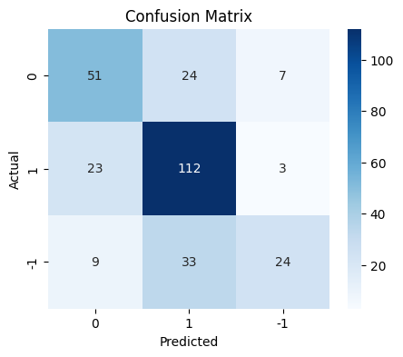

```python
plot_confusion_matrix(base_wv,X_train_wv,y_train)
```

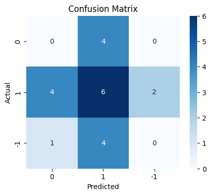

```python
plot_confusion_matrix(base_wv,X_val_wv,y_val)
```

```python
#Calculating different metrics on training data
base_train_wv = model_performance_classification_sklearn(base_wv,X_train_wv,y_train)
print("Training performance:\n", base_train_wv)
```

```
Training performance:
    Accuracy    Recall  Precision        F1
0  0.653846  0.653846   0.658844  0.640075
```

```python
#Calculating different metrics on validation data
base_val_wv = model_performance_classification_sklearn(base_wv,X_val_wv,y_val)
print("Validation performance:\n",base_val_wv)
```

```
Validation performance:
    Accuracy    Recall  Precision        F1
0  0.285714  0.285714   0.244898  0.263736
```

### Base Model - GloVe

```python
#Building the model

# tried with all
#base_gl = GradientBoostingClassifier(random_state=42)
#base_gl = RandomForestClassifier(random_state=42)
#base_gl = DecisionTreeClassifier(random_state=42)

from sklearn.ensemble import AdaBoostClassifier
base_gl = AdaBoostClassifier(random_state=42)

# Fitting on train data
base_gl.fit(X_train_gl, y_train)
```

```
AdaBoostClassifier(random_state=42)
```

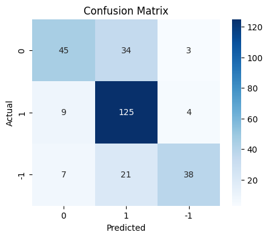

```python
# Plot the confusion matrix for the train data
plot_confusion_matrix(base_gl,X_train_gl,y_train)
```

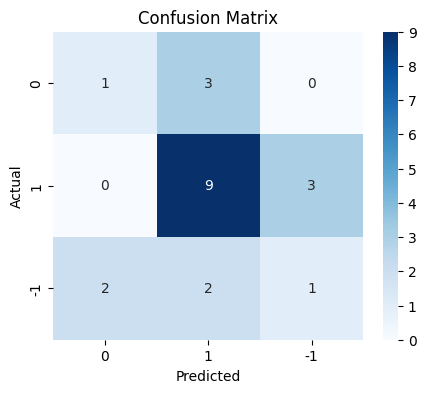

```python
# Plot the confusion matrix for the validation data
plot_confusion_matrix(base_gl,X_val_gl,y_val)
```

```python
#Calculating different metrics on training data
base_train_gl=model_performance_classification_sklearn(base_gl,X_train_gl,y_train)
print("Training performance:\n", base_train_gl)
```

```
Training performance:
    Accuracy    Recall  Precision        F1
0  0.727273  0.727273   0.741463  0.717791
```

```python
#Calculating different metrics on validation data
base_val_gl = model_performance_classification_sklearn(base_gl,X_val_gl,y_val)
print("Validation performance:\n",base_val_gl)
```

```
Validation performance:
    Accuracy   Recall  Precision        F1
0   0.52381  0.52381   0.490363  0.502936
```

### Base Model - Sentence Transformer

```python
# Building the model

# tried with all
#base_st = GradientBoostingClassifier(random_state=42)
#base_st = RandomForestClassifier(random_state=42)
#base_st = DecisionTreeClassifier(random_state=42)

from sklearn.ensemble import AdaBoostClassifier
base_st = AdaBoostClassifier(random_state=42)

# Fitting on train data
base_st.fit(X_train_st, y_train)
```

```
AdaBoostClassifier(random_state=42)
```

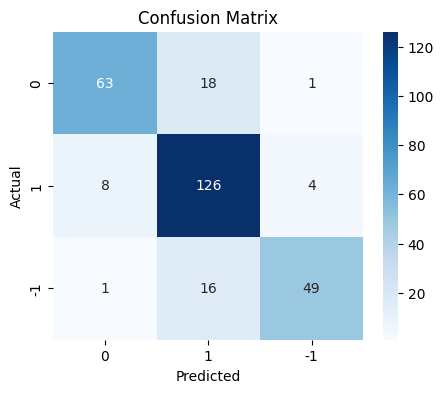

```python
# Plot the confusion matrix for the train data
plot_confusion_matrix(base_st,X_train_st,y_train)
```

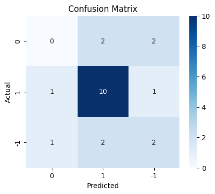

```python
# Plot the confusion matrix for the validation data
plot_confusion_matrix(base_st,X_val_st,y_val)
```

```python
#Calculating different metrics on training data
base_train_st=model_performance_classification_sklearn(base_st,X_train_st,y_train)
print("Training performance:\n", base_train_st)
```

```
Training performance:
    Accuracy    Recall  Precision       F1
0  0.832168  0.832168   0.840258  0.83108
```

```python
#Calculating different metrics on validation data
base_val_st = model_performance_classification_sklearn(base_st,X_val_st,y_val)
print("Validation performance:\n",base_val_st)
```

```
Validation performance:
    Accuracy    Recall  Precision        F1
0  0.571429  0.571429   0.503401  0.534799
```

### Tuned Model - Word2Vec

**Note**: The parameter grid provided below is a sample grid. It can be modified depending on the compute power of the system being used.

```python
start = time.time()

# Choose the type of classifier.
# tried all

#tuned_wv = GradientBoostingClassifier(random_state=42)
#tuned_wv = RandomForestClassifier(random_state=42)
#tuned_wv = DecisionTreeClassifier(random_state=42)

from sklearn.ensemble import AdaBoostClassifier
tuned_wv = AdaBoostClassifier(random_state=42)

parameters = {
#    'max_depth': np.arange(3,7),
#    'min_samples_split': np.arange(5,12,2),
#    'max_features': ['log2', 'sqrt', 0.2, 0.4]
#}

# AdaBoostClassifier parameters
    'n_estimators': [50, 100, 200],
    'learning_rate': [0.01, 0.1, 1.0]
}

# Run the grid search
grid_obj = GridSearchCV(tuned_wv, parameters, scoring='f1_weighted',cv=5,n_jobs=-1)
grid_obj = grid_obj.fit(X_train_wv, y_train)

end = time.time()
print("Time taken ",(end-start))

# Set the clf to the best combination of parameters
tuned_wv = grid_obj.best_estimator_
```

```
Time taken  15.336552858352661
```

```python
# Fit the best algorithm to the data.
tuned_wv.fit(X_train_wv, y_train)
```

```
AdaBoostClassifier(random_state=42)
```

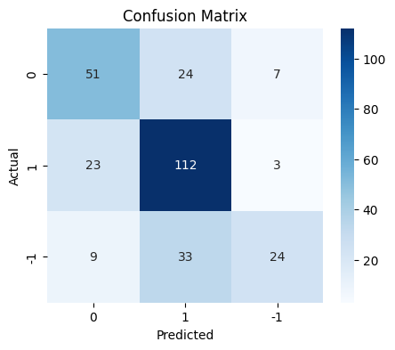

```python
plot_confusion_matrix(tuned_wv,X_train_wv,y_train)
```

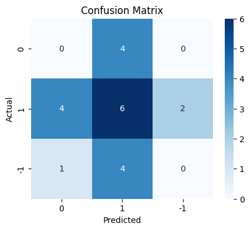

```python
plot_confusion_matrix(tuned_wv,X_val_wv,y_val)
```

```python
#Calculating different metrics on training data
tuned_train_wv=model_performance_classification_sklearn(tuned_wv,X_train_wv,y_train)
print("Training performance:\n",tuned_train_wv)
```

```
Training performance:
    Accuracy    Recall  Precision        F1
0  0.653846  0.653846   0.658844  0.640075
```

```python
#Calculating different metrics on validation data
tuned_val_wv = model_performance_classification_sklearn(tuned_wv,X_val_wv,y_val)
print("Validation performance:\n",tuned_val_wv)
```

```
Validation performance:
    Accuracy    Recall  Precision        F1
0  0.285714  0.285714   0.244898  0.263736
```

### Tuned Model - GloVe

```python
start = time.time()

# checked for all
#tuned_gl = GradientBoostingClassifier(random_state=42)
#tuned_gl = RandomForestClassifier(random_state=42)
#tuned_gl = DecisionTreeClassifier(random_state=42)


from sklearn.ensemble import AdaBoostClassifier
tuned_gl = AdaBoostClassifier(random_state=42)

parameters = {
#    'max_depth': np.arange(3,7),
#    'min_samples_split': np.arange(5,12,2),
#    'max_features': ['log2', 'sqrt', 0.2, 0.4]
#}

# AdaBoostClassifier parameters
    'n_estimators': [50, 100, 200],
    'learning_rate': [0.01, 0.1, 1.0]
}


# Run the grid search
grid_obj = GridSearchCV(tuned_gl, parameters, scoring='f1_weighted',cv=5,n_jobs=-1)
grid_obj = grid_obj.fit(X_train_gl, y_train)

end = time.time()
print("Time taken ",(end-start))

# Set the clf to the best combination of parameters
tuned_gl = grid_obj.best_estimator_
```

```
Time taken  4.28858494758606
```

```python
# Fit the best algorithm to the data.
tuned_gl.fit(X_train_gl, y_train)
```

```
AdaBoostClassifier(random_state=42)
```

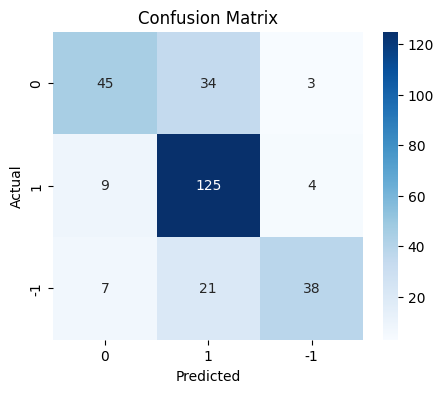

```python
# Plot the confusion matrix for the train data
plot_confusion_matrix(tuned_gl,X_train_gl,y_train)
```

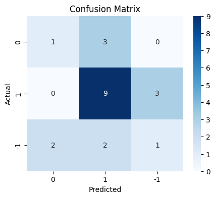

```python
# Plot the confusion matrix for the validation data
plot_confusion_matrix(tuned_gl,X_val_gl,y_val)
```

```python
#Calculating different metrics on training data
tuned_train_gl=model_performance_classification_sklearn(tuned_gl,X_train_gl,y_train)
print("Training performance:\n",tuned_train_gl)
```

```
Training performance:
    Accuracy    Recall  Precision        F1
0  0.727273  0.727273   0.741463  0.717791
```

```python
#Calculating different metrics on validation data
tuned_val_gl = model_performance_classification_sklearn(tuned_gl,X_val_gl,y_val)
print("Validation performance:\n",tuned_val_gl)
```

```
Validation performance:
    Accuracy   Recall  Precision        F1
0   0.52381  0.52381   0.490363  0.502936
```